# Защита лабораторной работы №8 Модель конкуренции двух фирм

Математическое моделирование

Махорин И. С.

Российский университет дружбы народов имени Патриса Лумумбы, Москва, Россия

2024

## Докладчик

- Махорин Иван Сергеевич
- Студент группы НПИбд-02-21
- Студ. билет 1032211221
- Российский университет дружбы народов имени Патриса Лумумбы

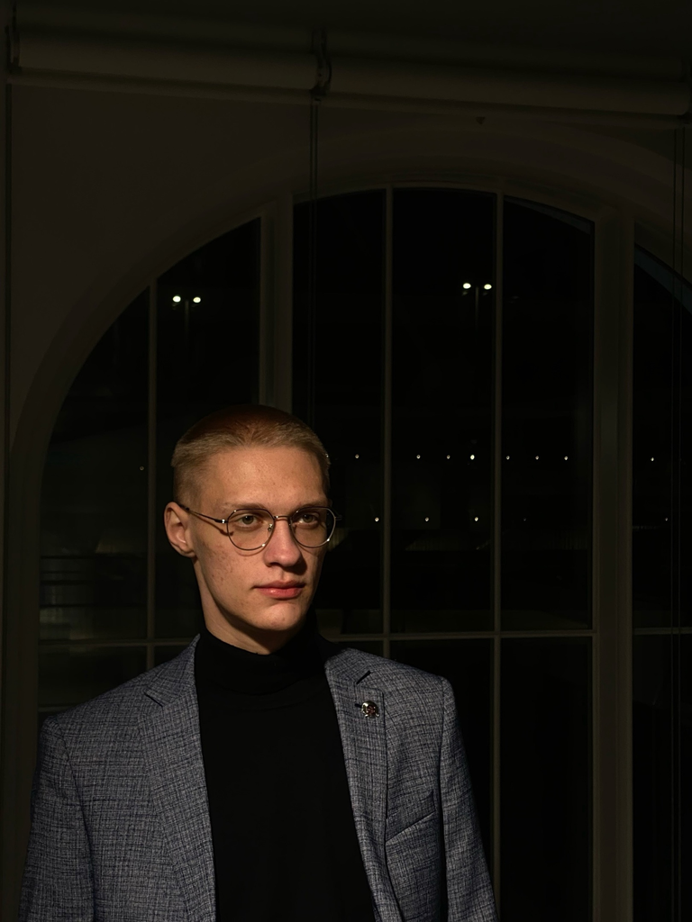

## Цель лабораторной работы

- Изучить и построить модель конкуренции двух фирм

## Теоретическое введние

Для построения модели конкуренции хотя бы двух фирм необходимо рассмотреть модель одной фирмы. Вначале рассмотрим модель фирмы, производящей продукт долговременного пользования, когда цена его определяется балансом спроса и предложения. Примем, что этот продукт занимает определенную нишу рынка и конкуренты в ней отсутствуют.

## Теоретическое введние

Обозначим:

*N* - число потребителей производимого продукта.

*S* – доходы потребителей данного продукта. Считаем, что доходы всех потребителей одинаковы. Это предположение справедливо, если речь идет об одной рыночной нише, т.е. производимый продукт ориентирован на определенный слой населения.

*M* – оборотные средства предприятия

*τ* - длительность производственного цикла

*p* - рыночная цена товара

*p̃* - себестоимость продукта, то есть переменные издержки на производство единицы продукции

*δ* - доля оборотных средств, идущая на покрытие переменных издержек

*k* - постоянные издержки, которые не зависят от количества выпускаемой продукции

*Q*(*S*/*p*) – функция спроса, зависящая от отношения дохода *S* к цене *p*. Она равна количеству продукта, потребляемого одним потребителем в единицу времени.

## Теоретическое введние. Построение математической модели (1)

Функцию спроса товаров долговременного использования часто представляют в простейшей форме:

$$Q = q - k\frac{p}{S} = q(1 -
\frac{p}{p_{cr}})$$

где *q* – максимальная потребность одного человека в продукте в единицу времени. Эта функция падает с ростом цены и при *p* = *p*<sub>*c**r*</sub> (критическая стоимость продукта) потребители отказываются от приобретения товара. Величина *p*<sub>*c**r*</sub> = *S**q*/*k*. Параметр *k* – мера эластичности функции спроса по цене. Таким образом, функция спроса является пороговой (то есть, *Q*(*S*/*p*) = 0 при *p* ≥ *p*<sub>*c**r*</sub>) и обладает свойствами насыщения.

## Теоретическое введние. Построение математической модели (2)

Уравнения динамики оборотных средств приобретает (1):

$$\frac{dM}{dt} = -\frac{M \delta}{\tau} +
NQp - k = -\frac{M\delta}{\tau} + Nq(1 - \frac{p}{p_{cr}})p -
k$$

## Теоретическое введние. Построение математической модели (3)

Уравнения динамики оборотных средств приобретает (2):

$$\frac{dM}{dt} = -\frac{M
\delta}{\tau}(\frac{p}{p_{cr}}-1) - M^2 ( \frac{\delta}{\tau
\widetilde{p} })^2 \frac{p_{cr}}{Nq} - k$$

## Теоретическое введние. Построение математической модели (4)

В обсуждаемой модели параметр *δ* всюду входит в сочетании с *τ*. Это значит, что уменьшение доли оборотных средств, вкладываемых в производство, эквивалентно удлинению производственного цикла. Поэтому мы в дальнейшем положим: *δ* = 1, а параметр *τ* будем считать временем цикла, с учётом сказанного.

## Задание лабораторной работы. Вариант 59

> Случай 1

Рассмотрим две фирмы, производящие взаимозаменяемые товары одинакового качества и находящиеся в одной рыночной нише. Считаем, что в рамках нашей модели конкурентная борьба ведётся только рыночными методами. То есть, конкуренты могут влиять на противника путем изменения параметров своего производства: себестоимость, время цикла, но не могут прямо вмешиваться в ситуацию на рынке («назначать» цену или влиять на потребителей каким-либо иным способом.) Будем считать, что постоянные издержки пренебрежимо малы, и в модели учитывать не будем. В этом случае динамика изменения объемов продаж фирмы 1 и фирмы 2 описывается следующей системой уравнений:

$$\frac{dM_1}{d\Theta} = M_1 -
\frac{b}{c_1}M_1 M_2 - \frac{a1}{c1} M_1^2$$

$$\frac{dM_2}{d\Theta} = \frac{c_2}{c_1}
M_2 - \frac{b}{c_1} M_1 M_2 - \frac{a_2}{c_1} M_2^2$$

где

$$a_1 = \frac{p_{cr}}{\tau_1^2
\widetilde{p}_1^2 Nq }$$
$$a_2 =
\frac{p_{cr}}{\tau_2^2 \widetilde{p}_2^2 Nq }$$
$$b = \frac{p_{cr}}{\tau_1^2 \widetilde{p}_1^2
\tau_2^2 \widetilde{p}_2^2 Nq}$$
$$c_1 = \frac{p_{cr} - \widetilde{p}_1}{\tau_1 \widetilde{p}_1}$$
$$c_2 = \frac{p_{cr} -
\widetilde{p}_2}{\tau_2 \widetilde{p}_2}$$

также введена нормировка *t* = *c*<sub>1</sub>*Θ*

## Задание лабораторной работы. Вариант 59

> Случай 2

Рассмотрим модель, когда, помимо экономического фактора влияния (изменение себестоимости, производственного цикла, использование кредита и т.п.), используются еще и социально-психологические факторы – формирование общественного предпочтения одного товара другому, не зависимо от их качества и цены. В этом случае взаимодействие двух фирм будет зависеть друг от друга, соответственно коэффициент перед *M*<sub>1</sub>*M*<sub>2</sub> будет отличаться. Пусть в рамках рассматриваемой модели динамика изменения объемов продаж фирмы 1 и фирмы 2 описывается следующей системой уравнений:

$$\frac{dM_1}{d\Theta} = M_1 -
(\frac{b}{c_1} + 0.00049)M_1 M_2 - \frac{a1}{c1} M_1^2$$

$$\frac{dM_2}{d\Theta} = \frac{c_2}{c_1}
M_2 - \frac{b}{c_1} M_1 M_2 - \frac{a_2}{c_1} M_2^2$$

Для обоих случаев рассмотрим задачу со следующими начальными условиями и параметрами

*M*<sub>0</sub><sup>1</sup> = 7 *M*<sub>0</sub><sup>2</sup> = 8.9 *p*<sub>*c**r*</sub> = 40 *N* = 45 *q* = 1 *τ*<sub>1</sub> = 25 *τ*<sub>2</sub> = 20 *p̃*<sub>1</sub> = 8 *p̃*<sub>2</sub> = 8.5

## Задачи

1. Изучить модель конкуренции двух фирм
2. Построить графики изменения оборотных средств двух фирм для обоих случаев

# Ход выполнения лабораторной работы

## Математическая модель

По представленному выше теоретическому материалу были составлены модели на обоих языках программирования.

# Решение с помощью программ

## Результаты работы кода на Julia и Open Modelica для первого случая:

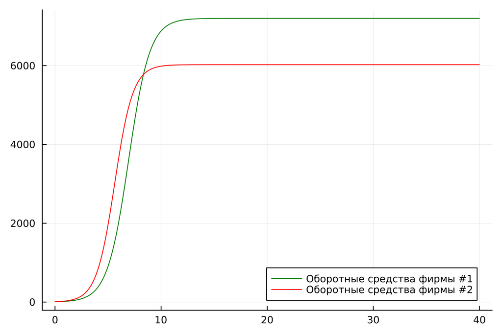

“График, построенный на языке Julia”

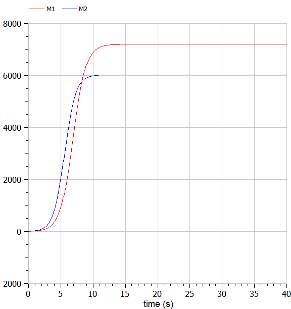

“График, построенный на языке Open Modelica”

## Результаты работы кода на Julia и Open Modelica для второго случая:

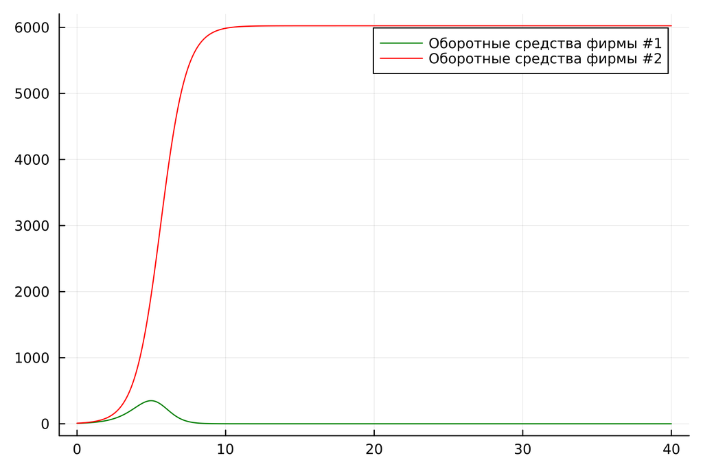

“График, построенный на языке Julia”

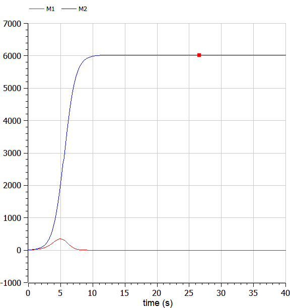

“График, построенный на языке Open Modelica”

## Анализ полученных результатов. Сравнение языков.

- В итоге проделанной работы на языках Julia и OpenModelica мы построили графики изменения оборотных средств для двух фирм для случаев, когда конкурентная борьба ведётся только рыночными методами и когда, помимо экономического фактора влияния, используются еще и социально-психологические факторы
- Кроме того, построение модели конкуренции двух фирм на языке OpenModelica занимает значительно меньше строк кода, чем аналогичное построение на Julia

# Вывод

## Вывод

В ходе выполнения лабораторной работы была изучена модель конкуренции двух фирм и в дальнейшем построена модель на языках Julia и Open Modelica.

## Список литературы. Библиография

[1] Документация по Julia: https://docs.julialang.org/en/v1/

[2] Документация по OpenModelica: https://openmodelica.org/

[3] Решение дифференциальных уравнений: https://www.wolframalpha.com/

[4] Мальтузианская модель роста: https://www.stolaf.edu//people/mckelvey/envision.dir/malthus.html

[5] Математические модели конкурентной среды: https://dspace.spbu.ru/bitstream/11701/12019/1/Gorynya_2018.pdf

[6] Разработка математических моделей конкурентных процессов: https://www.academia.edu/9284004/Наумейко_РАЗРАБОТКА_МАТЕМАТИЧЕСКОЙ_МОДЕЛИ_КОНКУРЕНТНЫХ_ПРОЦЕССОВ